# Loan Prediction

## Machine Learning course Project phase I - 2021

### Group Name - Group 41

### Names and Student IDs

- Soniya Birla (S3807555)
- Chitrakshi Prajapat (S3807598)
- Sawan Baberwal (S3829613)

## Table of Content

- Introduction
- Goals & Objective
- Data Cleaning & Preprocessing
- Data Visualisation
- Summary & Conclusion

# Introduction

Loan prediction is a very basic real-life issue that any retail bank will face at some point during its existence. It can save a lot of man hours at the end of a retail bank if done correctly.Banks' primary business is lending. The primary source of benefit is the interest on the loan. After an extensive verification and confirmation process, the loan companies issue a loan. They may not, however, have guarantees that the borrower will be able to repay the loan without difficulty.

There is a company called Dream House finance company which deals in all type of Loans and have made their presence across all rural, semi-urban and urban areas. They want to build up this process where they automate the eligibilty process based on the details provided by the applicants via online application form.

The aim of Phase I of this study is to look into the impact of various factors on predicting the applicant's probablity status. Many variables, such as Gender, Marital Status, Number of Dependents, Income, Loan Amount, Credit History, and others, have been discovered to play a significant role in predicting eligibility status.

### Dataset Source

The data is Sourced from (https://www.kaggle.com/altruistdelhite04/loan-prediction-problem-dataset?select=train_u6lujuX_CVtuZ9i.csv). The data set includes 614 observations and 13 feature information

### Dataset Details

The data is about loan status getting approved or not for an individual taking various factors into consideration such as how much is the loan amount they have applied for or whether its a Male or Female or depending on it Credit History or how many dependents he/she has etc. These all factors will help us in predicting whether an individual will be able to repay the amount or not depending on which a loan of particular amount will be granted to him/her.

### Dataset Features

The variable descriptions below are:

[output not shown]

### Target Feature

The target feature for our project is "Loan_Status" which has two levels.

1. No="If Loan is not approved "
2. Yes="If Loan is approved"

We will be predicting **"The probablity of Loan approval"** based on the information received of the applicants.

# Goals & Objective

The goal of this study is to look into the impact of various factors on predicting the applicant's Loan approval status. Variables such as Gender, Marital Status, Number of Dependents, Loan Amount, Credit History, and others, have been discovered to play a significant role in predicting eligibility status.

# Data Cleaning and Preprocessing

## Preliminaries

Firstly, we will import all the common modules we will be using in this report.

```python
# Importing modules
import numpy as np
import pandas as pd
import matplotlib.pyplot as plt
import seaborn as sns
import warnings
###
warnings.filterwarnings('ignore')
###
%matplotlib inline
%config InlineBackend.figure_format = 'retina'
plt.style.use("ggplot")
```

We have downloaded the data as Csv file. Now we have imported the data using read_csv

### Importing the data

```python
# Importing the data
loan = pd.read_csv("/Users/soniyabirla/Downloads/Data_Group41.csv")
```

```python
loan.head()
```

|  | Loan_ID | Gender | Married | Dependents | Education | Self_Employed | ApplicantIncome | CoapplicantIncome | LoanAmount | Loan_Amount_Term | Credit_History | Property_Area | Loan_Status |
| --- | --- | --- | --- | --- | --- | --- | --- | --- | --- | --- | --- | --- | --- |
| 0 | LP001002 | Male | No | 0 | Graduate | No | 5849 | 0.0 | NaN | 360.0 | 1.0 | Urban | Y |
| 1 | LP001003 | Male | Yes | 1 | Graduate | No | 4583 | 1508.0 | 128.0 | 360.0 | 1.0 | Rural | N |
| 2 | LP001005 | Male | Yes | 0 | Graduate | Yes | 3000 | 0.0 | 66.0 | 360.0 | 1.0 | Urban | Y |
| 3 | LP001006 | Male | Yes | 0 | Not Graduate | No | 2583 | 2358.0 | 120.0 | 360.0 | 1.0 | Urban | Y |
| 4 | LP001008 | Male | No | 0 | Graduate | No | 6000 | 0.0 | 141.0 | 360.0 | 1.0 | Urban | Y |

```python
loan.shape
```

```
(614, 13)
```

```python
loan.info()
```

```
<class 'pandas.core.frame.DataFrame'>
RangeIndex: 614 entries, 0 to 613
Data columns (total 13 columns):
 #   Column             Non-Null Count  Dtype
---  ------             --------------  -----
 0   Loan_ID            614 non-null    object
 1   Gender             601 non-null    object
 2   Married            611 non-null    object
 3   Dependents         599 non-null    object
 4   Education          614 non-null    object
 5   Self_Employed      582 non-null    object
 6   ApplicantIncome    614 non-null    int64
 7   CoapplicantIncome  614 non-null    float64
 8   LoanAmount         592 non-null    float64
 9   Loan_Amount_Term   600 non-null    float64
 10  Credit_History     564 non-null    float64
 11  Property_Area      614 non-null    object
 12  Loan_Status        614 non-null    object
dtypes: float64(4), int64(1), object(8)
memory usage: 62.5+ KB
```

We discovered the following details about the dataset after summarising the data:

- A total of 614 observations and 13 variables are included in this study. We have seven categorical features, one of which is the Target feature (Loan Status), four numerical features, and one binary feature.
- The Loan ID column is used to keep track of which loans have been made.
- Gender, Married, Education, Self Employed, and Loan Status are the Categorical Features that have two levels.

```python
loan.describe(include='all')
```

|  | Loan_ID | Gender | Married | Dependents | Education | Self_Employed | ApplicantIncome | CoapplicantIncome | LoanAmount | Loan_Amount_Term | Credit_History | Property_Area | Loan_Status |
| --- | --- | --- | --- | --- | --- | --- | --- | --- | --- | --- | --- | --- | --- |
| count | 614 | 601 | 611 | 599 | 614 | 582 | 614.000000 | 614.000000 | 592.000000 | 600.00000 | 564.000000 | 614 | 614 |
| unique | 614 | 2 | 2 | 4 | 2 | 2 | NaN | NaN | NaN | NaN | NaN | 3 | 2 |
| top | LP002449 | Male | Yes | 0 | Graduate | No | NaN | NaN | NaN | NaN | NaN | Semiurban | Y |
| freq | 1 | 489 | 398 | 345 | 480 | 500 | NaN | NaN | NaN | NaN | NaN | 233 | 422 |
| mean | NaN | NaN | NaN | NaN | NaN | NaN | 5403.459283 | 1621.245798 | 146.412162 | 342.00000 | 0.842199 | NaN | NaN |
| std | NaN | NaN | NaN | NaN | NaN | NaN | 6109.041673 | 2926.248369 | 85.587325 | 65.12041 | 0.364878 | NaN | NaN |
| min | NaN | NaN | NaN | NaN | NaN | NaN | 150.000000 | 0.000000 | 9.000000 | 12.00000 | 0.000000 | NaN | NaN |
| 25% | NaN | NaN | NaN | NaN | NaN | NaN | 2877.500000 | 0.000000 | 100.000000 | 360.00000 | 1.000000 | NaN | NaN |
| 50% | NaN | NaN | NaN | NaN | NaN | NaN | 3812.500000 | 1188.500000 | 128.000000 | 360.00000 | 1.000000 | NaN | NaN |
| 75% | NaN | NaN | NaN | NaN | NaN | NaN | 5795.000000 | 2297.250000 | 168.000000 | 360.00000 | 1.000000 | NaN | NaN |
| max | NaN | NaN | NaN | NaN | NaN | NaN | 81000.000000 | 41667.000000 | 700.000000 | 480.00000 | 1.000000 | NaN | NaN |

We changed the type of variable(Credit_History) to Object type because it can be seen that it has two unique values i.e 0 & 1

```python
loan['Credit_History'] = loan['Credit_History'].astype('O')
```

```python
loan.info()
```

```
<class 'pandas.core.frame.DataFrame'>
RangeIndex: 614 entries, 0 to 613
Data columns (total 13 columns):
 #   Column             Non-Null Count  Dtype
---  ------             --------------  -----
 0   Loan_ID            614 non-null    object
 1   Gender             601 non-null    object
 2   Married            611 non-null    object
 3   Dependents         599 non-null    object
 4   Education          614 non-null    object
 5   Self_Employed      582 non-null    object
 6   ApplicantIncome    614 non-null    int64
 7   CoapplicantIncome  614 non-null    float64
 8   LoanAmount         592 non-null    float64
 9   Loan_Amount_Term   600 non-null    float64
 10  Credit_History     564 non-null    object
 11  Property_Area      614 non-null    object
 12  Loan_Status        614 non-null    object
dtypes: float64(3), int64(1), object(9)
memory usage: 62.5+ KB
```

## Checking for Missing Values

```python
print(f"\nNumber of missing values for each feature:")
print(loan.isnull().sum())
```

```
Number of missing values for each feature:
Loan_ID               0
Gender               13
Married               3
Dependents           15
Education             0
Self_Employed        32
ApplicantIncome       0
CoapplicantIncome     0
LoanAmount           22
Loan_Amount_Term     14
Credit_History       50
Property_Area         0
Loan_Status           0
dtype: int64
```

Since there are so many missing values, we can't just leave them out. Categorical Variables account for the majority of missing values. As a result, we can consider the following approaches to fill in the missing values:

- For numerical variables, use mean or median imputation.
- For categorical variables, use mode imputation.

```python
loan['Gender'].value_counts()
```

```
Male      489
Female    112
Name: Gender, dtype: int64
```

```python
loan.Gender = loan.Gender.fillna('Male')
```

```python
loan['Married'].value_counts()
```

```
Yes    398
No     213
Name: Married, dtype: int64
```

```python
loan.Married = loan.Married.fillna('Yes')
```

```python
loan['Dependents'].value_counts()
```

```
0     345
1     102
2     101
3+     51
Name: Dependents, dtype: int64
```

```python
loan.Dependents = loan.Dependents.fillna('0')
```

```python
loan['Self_Employed'].value_counts()
```

```
No     500
Yes     82
Name: Self_Employed, dtype: int64
```

```python
loan.Self_Employed = loan.Self_Employed.fillna('No')
```

```python
loan.LoanAmount = loan.LoanAmount.fillna(loan.LoanAmount.mean())
```

```python
loan['Loan_Amount_Term'].value_counts()
```

```
360.0    512
180.0     44
480.0     15
300.0     13
84.0       4
240.0      4
120.0      3
36.0       2
60.0       2
12.0       1
Name: Loan_Amount_Term, dtype: int64
```

```python
loan.Loan_Amount_Term = loan.Loan_Amount_Term.fillna(360.0)
```

```python
loan['Credit_History'].value_counts()
```

```
1.0    475
0.0     89
Name: Credit_History, dtype: int64
```

```python
loan.Credit_History = loan.Credit_History.fillna(1.0)
```

```python
loan.isnull().sum()
```

```
Loan_ID              0
Gender               0
Married              0
Dependents           0
Education            0
Self_Employed        0
ApplicantIncome      0
CoapplicantIncome    0
LoanAmount           0
Loan_Amount_Term     0
Credit_History       0
Property_Area        0
Loan_Status          0
dtype: int64
```

We provide descriptive namings in categories for a clearer understanding of categories in visualisation.

```python
loan['Credit_History'] = loan['Credit_History'].replace(0, 'No').replace(1, 'Yes')
```

```python
loan['Loan_Status'] = loan['Loan_Status'].replace('Y', 'Approved').replace('N', 'Not Approved')
```

```python
loan.head()
```

|  | Loan_ID | Gender | Married | Dependents | Education | Self_Employed | ApplicantIncome | CoapplicantIncome | LoanAmount | Loan_Amount_Term | Credit_History | Property_Area | Loan_Status |
| --- | --- | --- | --- | --- | --- | --- | --- | --- | --- | --- | --- | --- | --- |
| 0 | LP001002 | Male | No | 0 | Graduate | No | 5849 | 0.0 | 146.412162 | 360.0 | Yes | Urban | Approved |
| 1 | LP001003 | Male | Yes | 1 | Graduate | No | 4583 | 1508.0 | 128.000000 | 360.0 | Yes | Rural | Not Approved |
| 2 | LP001005 | Male | Yes | 0 | Graduate | Yes | 3000 | 0.0 | 66.000000 | 360.0 | Yes | Urban | Approved |
| 3 | LP001006 | Male | Yes | 0 | Not Graduate | No | 2583 | 2358.0 | 120.000000 | 360.0 | Yes | Urban | Approved |
| 4 | LP001008 | Male | No | 0 | Graduate | No | 6000 | 0.0 | 141.000000 | 360.0 | Yes | Urban | Approved |

# Data Visualisation

### Loan Status

We can see at the barplot that the number of applicants who received a loan approval which is about 69% is much higher than the number of applicants who did not receive a loan approval which is 31%.

```python
table = pd.crosstab(index=loan['Loan_Status'], columns='count',normalize=True).round(decimals=2)
table.columns = ["count"]
table.index= ["Approved","Not Approved"]

table
```

|  | count |
| --- | --- |
| Approved | 0.69 |
| Not Approved | 0.31 |

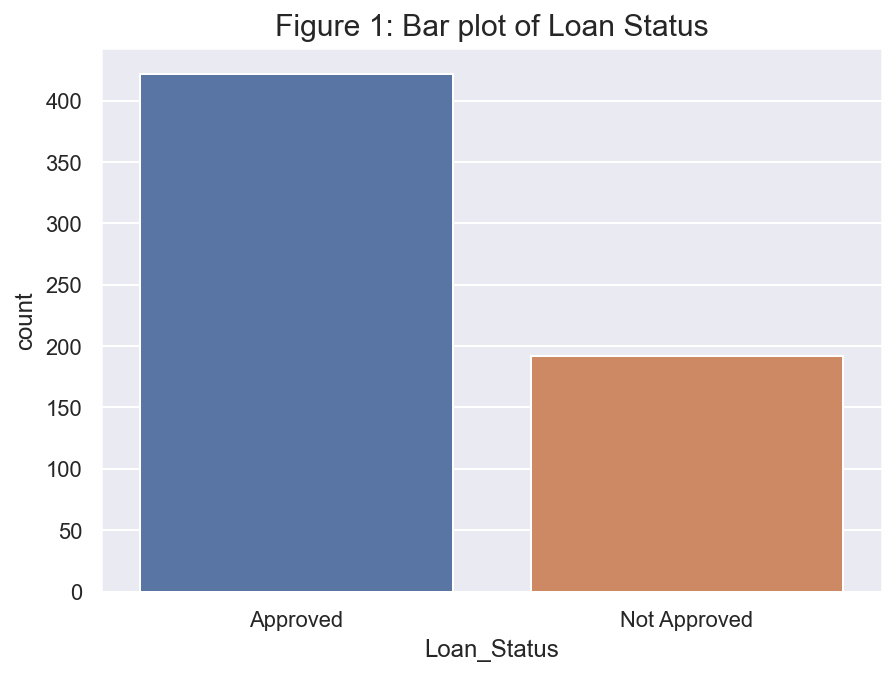

```python
sns.set_theme(style="darkgrid")
plt.figure(figsize=(7,5))
P1 = sns.countplot(x="Loan_Status", data=loan).set_title('Figure 1: Bar plot of Loan Status', fontsize = 15)
```

## Descriptive Features

### Gender

The plot shows that Males outnumber females in the applicant pool.Also when compared Males have a higher chance of being accepted for the loan.

```python
table = pd.crosstab(index=loan["Gender"],
                            columns=loan["Loan_Status"],normalize=True).round(decimals=2)

table.columns = ["Approved", "Not Approved"]
table.index= ["Female","Male"]

table
```

|  | Approved | Not Approved |
| --- | --- | --- |
| Female | 0.12 | 0.06 |
| Male | 0.57 | 0.25 |

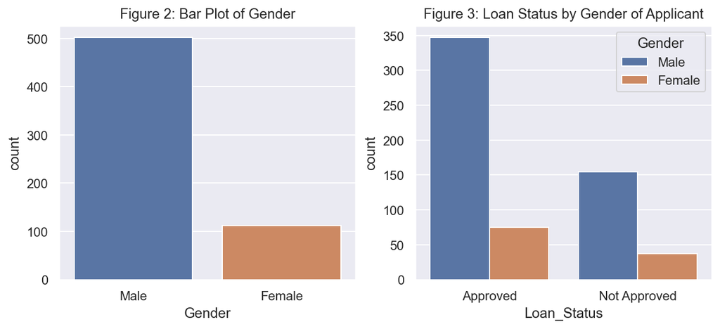

```python
fig = plt.figure(figsize=(10,4))

#  subplot #1
plt.subplot(121)
sns.countplot(data = loan, x = 'Gender')
plt.title('Figure 2: Bar Plot of Gender',fontsize = 12)

#  subplot #2
plt.subplot(122)
sns.countplot(data = loan, x = 'Loan_Status', hue = 'Gender')
plt.title('Figure 3: Loan Status by Gender of Applicant',fontsize = 12)
plt.show()
```

### Education

The plot shows that proportion of Loan applied by graduates are more than the proportion of loan applied by non graduates. Also application of the Graduates are more likely to be approved than non graduates.

```python
table = pd.crosstab(index=loan["Education"],
                            columns=loan["Loan_Status"],normalize=True).round(decimals=2)

table.columns = ["Approved", "Not Approved"]
table.index= ["Graduate","Not Graduate"]

table
```

|  | Approved | Not Approved |
| --- | --- | --- |
| Graduate | 0.55 | 0.23 |
| Not Graduate | 0.13 | 0.08 |

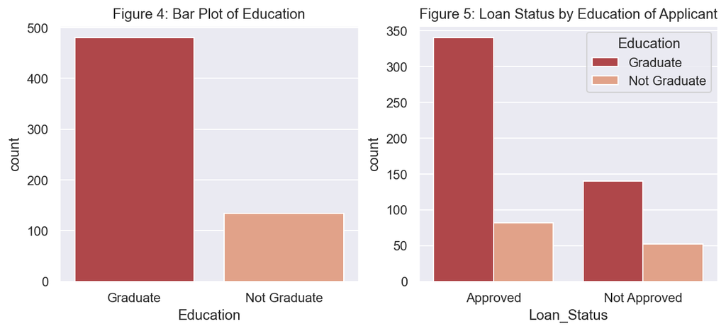

```python
sns.set_palette("RdBu")
fig = plt.figure(figsize=(10,4))

#  subplot #1
plt.subplot(121)
sns.countplot(data = loan, x = 'Education')
plt.title('Figure 4: Bar Plot of Education',fontsize = 12)

#  subplot #2
plt.subplot(122)
sns.countplot(data = loan, x = 'Loan_Status', hue = 'Education')
plt.title('Figure 5: Loan Status by Education of Applicant', fontsize = 12)
plt.show()
```

### Number Of Dependents

```python
table = pd.crosstab(index=loan["Dependents"],
                            columns=loan["Loan_Status"],normalize=True).round(decimals=2)

table.columns = ["Approved", "Not Approved"]
table.index= ["0", "1", "2", "3+"]

table
```

|  | Approved | Not Approved |
| --- | --- | --- |
| 0 | 0.40 | 0.18 |
| 1 | 0.11 | 0.06 |
| 2 | 0.12 | 0.04 |
| 3+ | 0.05 | 0.03 |

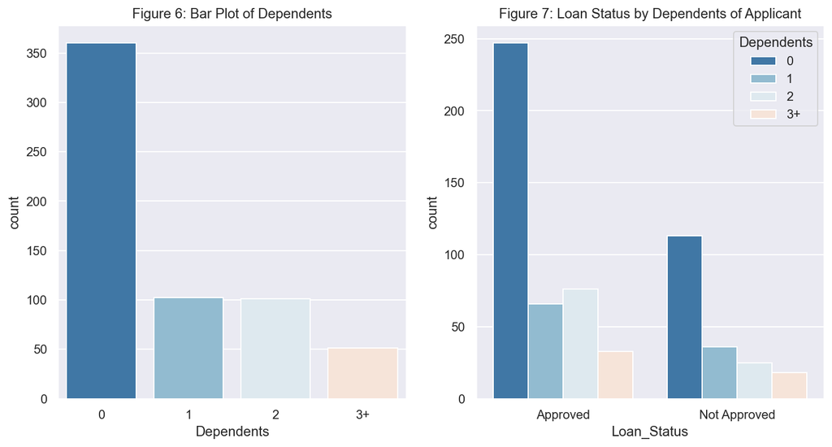

```python
sns.set_palette("RdBu_r")
fig = plt.figure(figsize=(12,6))

#  subplot #1
plt.subplot(121)
sns.countplot(data = loan, x = 'Dependents')
plt.title('Figure 6: Bar Plot of Dependents',fontsize = 12)

#  subplot #2
plt.subplot(122)
sns.countplot(data = loan, x = 'Loan_Status', hue = 'Dependents')
plt.title('Figure 7: Loan Status by Dependents of Applicant', fontsize = 12)
plt.show()
```

## Credit History

The plot shows that proportion of Loan applied by applicants who has previous credit History are more than the proportion of loan applied by applicants those who doesn't have. Also application who has credit history are more likely to be approved than those who doesn't have.

```python
table = pd.crosstab(index=loan["Credit_History"],
                            columns=loan["Loan_Status"],normalize=True).round(decimals=2)

table.columns = ["Approved", "Not Approved"]
table.index= ["No", "Yes"]

table
```

|  | Approved | Not Approved |
| --- | --- | --- |
| No | 0.01 | 0.13 |
| Yes | 0.68 | 0.18 |

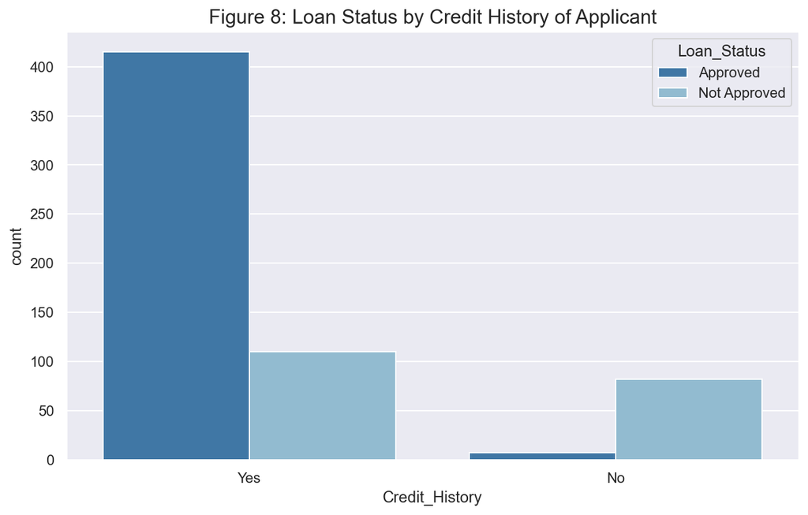

```python
fig = plt.figure(figsize=(10,6))
sns.countplot(data = loan, x = 'Credit_History', hue = 'Loan_Status')
plt.title('Figure 8: Loan Status by Credit History of Applicant', fontsize = 15)
plt.show()
```

### Loan Status, Property_Area and Credit History

It is evident from the below plot that there are high chances of loan getting approved if applicant has property area in Semi urban and has credit history, whereas there is negligible chances to get approved if applicant has property in urban area with no credit history.

```python
table = pd.crosstab(index=loan["Credit_History"],
                            columns=loan["Loan_Status"],normalize=True).round(decimals=2)

table.columns = ["Approved", "Not Approved"]
table.index= ["No", "Yes"]

table
```

|  | Approved | Not Approved |
| --- | --- | --- |
| No | 0.01 | 0.13 |
| Yes | 0.68 | 0.18 |

```python
table = pd.crosstab(index=loan["Property_Area"],
                            columns=loan["Loan_Status"],normalize=True).round(decimals=2)

table.columns = ["Approved", "Not Approved"]
table.index= ["Rural", "Semiurban", "urban"]

table
```

|  | Approved | Not Approved |
| --- | --- | --- |
| Rural | 0.18 | 0.11 |
| Semiurban | 0.29 | 0.09 |
| urban | 0.22 | 0.11 |

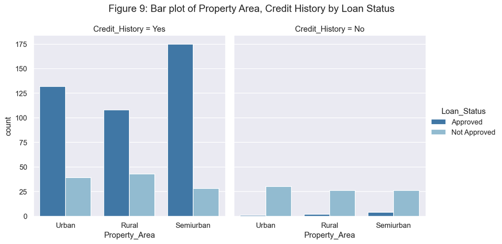

```python
P2 = sns.catplot(x="Property_Area", hue="Loan_Status", col="Credit_History",
                data=loan, kind="count",
                height=5, aspect=.9)
P2.fig.subplots_adjust(top=0.85) # adjust the Figure in P2
P2.fig.suptitle('Figure 9: Bar plot of Property Area, Credit History by Loan Status', fontsize = 15)
```

### Dependents, Loan Amount & Loan Status

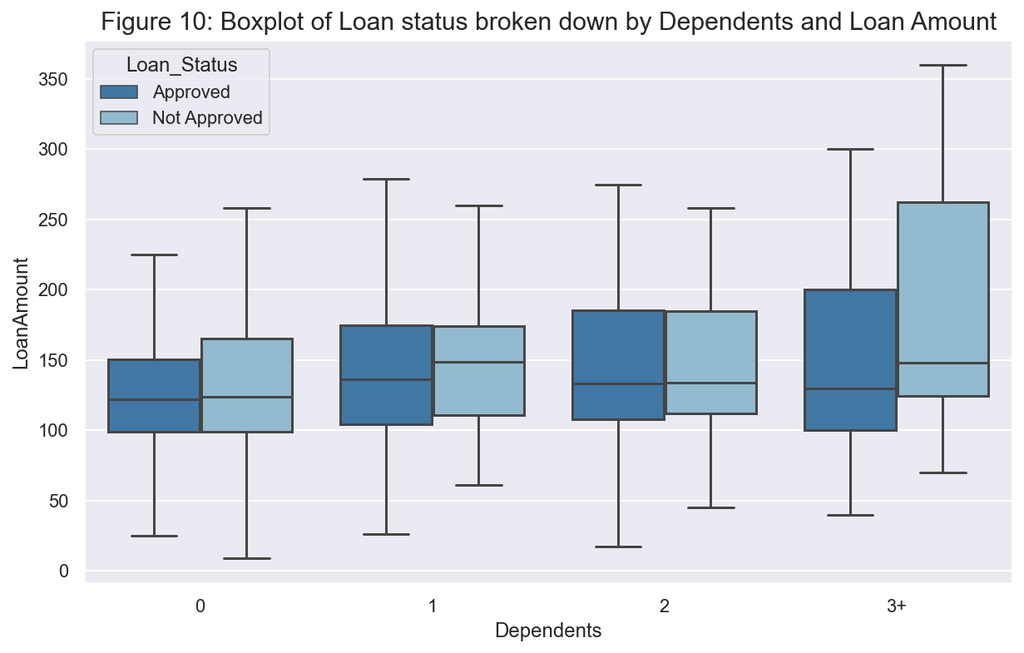

```python
plt.figure(figsize=(10,6))
sns.boxplot(loan['Dependents'], loan['LoanAmount'],
            hue = loan['Loan_Status'],showfliers=False, )
plt.title('Figure 10: Boxplot of Loan status broken down by Dependents and Loan Amount', fontsize = 15)
plt.show();
```

### Dependents, Gender & Loan Status

```python
table = pd.crosstab(index=loan["Gender"],
                            columns=loan["Loan_Status"],normalize=True).round(decimals=2)

table.columns = ["Approved", "Not Approved"]
table.index= ["Female", "Male"]

table
```

|  | Approved | Not Approved |
| --- | --- | --- |
| Female | 0.12 | 0.06 |
| Male | 0.57 | 0.25 |

```python
table = pd.crosstab(index=loan["Dependents"],
                            columns=loan["Loan_Status"],normalize=True).round(decimals=2)

table.columns = ["Approved", "Not Approved"]
table.index= ["0", "1", "2", "3+"]

table
```

|  | Approved | Not Approved |
| --- | --- | --- |
| 0 | 0.40 | 0.18 |
| 1 | 0.11 | 0.06 |
| 2 | 0.12 | 0.04 |
| 3+ | 0.05 | 0.03 |

[figure not shown]

```python
P3 = sns.FacetGrid(loan, hue ='Loan_Status', col = 'Gender', height = 6)
# map the above form facetgrid with some attributes
P3.map(sns.countplot, 'Dependents')
P3.add_legend()
P3.fig.subplots_adjust(top=0.85) # adjust the Figure in P2
P3.fig.suptitle('Figure 11: Bar plot of Dependents, Gender by Loan Status', fontsize = 15)
```